# Data Report

Hannah Schweren

2024-01-24

```r
#load necessary packages

library(rvest)
library(dplyr)
```

```r
library(stringr) #für word count
library(ggplot2)
library(legislatoR)
```

# Data import

After acquiring the data from the CLD containing the “wikititle”, I can use this to scrape the Wikipedia articles. I subsetted the data, only focusing on politicians that are still alive (death = NA) as I consider those politicians more relevant for my analysis, instead of including also rather historical figures.

```r
#import raw data

#raw data was acquired using the following code (using France as an example)
# fr_core <-  get_core((legislature = "fra"))
# fr_core_alive <- fr_core %>% filter(is.na(death))

###text aquisition german (using german as example)

# de_text_pipeline <- function(page_name) {
#   Sys.sleep(runif(1, 1, 2))
#
#   # Check if page_name is missing
#   if (is.na(page_name) || page_name == "") {
#     return("No Wikipedia page name provided or missing.")
#   }
#
#   # Try fetching Wikipedia content
#   tryCatch({
#     wp_content <- WikipediR::page_content("de", "wikipedia", page_name = page_name)
#     plain_text <- html_text(read_html(wp_content$parse$text$`*`))
#     return(plain_text)
#   }, error = function(e) {
#     return(paste("Error fetching content for page:", page_name))
#   })
# }


cze_alive_text <- read.csv("raw_data/cze_alive_text.csv")

deu_alive_text <- read.csv("raw_data/deu_alive_text.csv")

fr_alive_text <- read.csv("raw_data/fr_alive_text.csv")

usa_alive_text <- read.csv("raw_data/usa_alive_text.csv")

gbr_alive_text <- read.csv("raw_data/gbr_alive_text.csv")

sco_alive_text <- read.csv("raw_data/sco_alive_text.csv")

irl_alive_text <- read.csv("raw_data/irl_alive_text.csv")

esp_alive_text <- read.csv("raw_data/esp_alive_text.csv")

can_alive_text <- read.csv("raw_data/can_alive_text.csv")

aut_alive_text <- read.csv("raw_data/aut_alive_text.csv")
```

# functions

```r
# Necessary functions for the following data preprocessing

clean_data <- function(df) {
  initial_rows <- nrow(df)

  # Remove CSS-like structures
  df$plain_text <- str_remove_all(df$plain_text, "\\..*?\\{.*?\\}")

  # Initialize counters for removal reasons
  removal_reason_redirect <- sum(grepl("^(Redirect to:|Weiterleitung nach:|Rediriger vers:|Redirige a:|Přesměrování na:)", df$plain_text, ignore.case = TRUE))
  removal_reason_refering_page <- sum(grepl("may refer to:|ist der Name folgender Personen:|Cette page d'homonymie répertorie différentes personnes|může být:", df$plain_text, ignore.case = TRUE))
  removal_reason_not_found <- sum(grepl("^(Error fetching content for page:|No Wikipedia page name provided or missing|Es wurde kein Wikipedia-Seitenname angegeben)", df$plain_text, ignore.case = TRUE))


  # Filter rows based on condition
  df <- df %>%
    filter(!grepl("^(Redirect to:|Weiterleitung nach:|Rediriger vers:|Redirige a:|Přesměrování na:)", plain_text, ignore.case = TRUE) &
             !grepl("may refer to:|ist der Name folgender Personen:|Cette page d'homonymie répertorie différentes personnes|může být:", plain_text, ignore.case = TRUE) &
             !grepl("Error fetching content for page:|No Wikipedia page name provided or missing|Es wurde kein Wikipedia-Seitenname angegeben", plain_text, ignore.case = TRUE))

  # Calculate the number of rows removed
  rows_removed <- initial_rows - nrow(df)

  # Print statistics about the removal reasons
  cat("Removal reasons:\n")
  cat("  - Redirect:", removal_reason_redirect, "\n")
  cat("  - Reference Page:", removal_reason_refering_page, "\n")
  cat("  - Not Found/no name_provided:", removal_reason_not_found, "\n")


  # Create a message about the cleaning process
  cat("Cleaned data: Removed", rows_removed, "rows.\n")

  # Return the cleaned data frame
  return(df)
}


traffic_metrics <- function(traffic_data) {
  # Format the date
  traffic_data$date <- format(traffic_data$date, "%Y-%m")

  # Total per politician
  total_traffic_per_politician <- traffic_data %>%
    group_by(pageid) %>%
    summarise(total_traffic = sum(traffic))

  # Average per month per politician
  average_traffic_per_politician <- total_traffic_per_politician %>%
    mutate(average_traffic = total_traffic / n_distinct(traffic_data$date))

  # Convert pageid to numeric
  average_traffic_per_politician$pageid <- as.numeric(average_traffic_per_politician$pageid)

  # Return the result
  return(average_traffic_per_politician)
}


count_words <- function(text) {
  words <- str_extract_all(text, "\\b\\w+\\b")[[1]]
  return(length(words))
}
```

the function to clean the data removes unreadable parts of the html format and leaves us with human readable text of the politician’s Wikipedia article. Further, it removes datapoints that didn’t succesfully retreive an article for reasons of redirects (name changes), missing Wikipedia pages ( no “wiki_title”) or references pages (“may refer to…”).

# data cleaning

```r
cze <- clean_data(cze_alive_text)
```

```
## Removal reasons:
##   - Redirect: 9
##   - Reference Page: 3
##   - Not Found/no name_provided: 1
## Cleaned data: Removed 13 rows.
```

```r
fra <- clean_data(fr_alive_text)
```

```
## Removal reasons:
##   - Redirect: 0
##   - Reference Page: 6
##   - Not Found/no name_provided: 1
## Cleaned data: Removed 7 rows.
```

```r
deu <- clean_data(deu_alive_text)
```

```
## Removal reasons:
##   - Redirect: 11
##   - Reference Page: 27
##   - Not Found/no name_provided: 4
## Cleaned data: Removed 42 rows.
```

```r
usa <- clean_data(usa_alive_text)
```

```
## Removal reasons:
##   - Redirect: 103
##   - Reference Page: 14
##   - Not Found/no name_provided: 0
## Cleaned data: Removed 117 rows.
```

```r
gbr <- clean_data(gbr_alive_text)
```

```
## Removal reasons:
##   - Redirect: 55
##   - Reference Page: 19
##   - Not Found/no name_provided: 1598
## Cleaned data: Removed 1672 rows.
```

```r
irl <- clean_data(irl_alive_text)
```

```
## Removal reasons:
##   - Redirect: 19
##   - Reference Page: 19
##   - Not Found/no name_provided: 0
## Cleaned data: Removed 38 rows.
```

```r
sco <- clean_data(sco_alive_text)
```

```
## Removal reasons:
##   - Redirect: 3
##   - Reference Page: 1
##   - Not Found/no name_provided: 0
## Cleaned data: Removed 4 rows.
```

```r
esp <- clean_data(esp_alive_text)
```

```
## Removal reasons:
##   - Redirect: 28
##   - Reference Page: 0
##   - Not Found/no name_provided: 1057
## Cleaned data: Removed 1085 rows.
```

```r
aut <- clean_data(aut_alive_text)
```

```
## Removal reasons:
##   - Redirect: 7
##   - Reference Page: 14
##   - Not Found/no name_provided: 5
## Cleaned data: Removed 26 rows.
```

```r
can <- clean_data(can_alive_text)
```

```
## Removal reasons:
##   - Redirect: 25
##   - Reference Page: 13
##   - Not Found/no name_provided: 0
## Cleaned data: Removed 38 rows.
```

I am using the “wikititle” as variable to use the API, which leads to some problems with redirects, when politicians changed their name after the creation of the CLD. Unfortunately, scraping via the “pageid” did not work out. The number of redirects seems still acceptable for me. A bigger problem is raised in the british and spanish data, where a lot of missing data occurs because of the page not being found. This is due to missing “wikititle” and “pageid”, which means that these politicians don’t have a unique Wikipedia page or Wikidata ID. To be discussed if this poses a problem for the further analysis of these countries’ politicians.

# data exploration

```r
#combine all data in one df

all_countries <- rbind(deu, cze, fra, usa, sco, irl, can, aut, esp, gbr)
all_countries <- all_countries%>%
  filter(!is.na(sex))
```

First, let’s have a look at the dataset, containing all countries and see how it is setup.

```r
head(all_countries)
```

```
##   country   pageid wikidataid         wikititle                 name    sex
## 1     DEU   174000    Q340387    Achim_Großmann       Achim Großmann   male
## 2     DEU  9980355  Q39678866     Achim_Kessler        Achim Kessler   male
## 3     DEU  5166669    Q340448        Achim_Post           Achim Post   male
## 4     DEU   261258    Q354647 Adelheid_Tröscher Adelheid D. Tröscher female
## 5     DEU 11924573  Q96096131    Adis_Ahmetovic       Adis Ahmetovic   male
## 6     DEU  3314903    Q363517    Adolf_Ostertag       Adolf Ostertag   male
##   ethnicity               religion      birth death        birthplace
## 1      <NA>            catholicism 1947-04-17    NA  50.77621,6.08379
## 2     white                   <NA> 1964-08-02    NA  48.12472,8.33083
## 3     white protestantism lutheran 1959-05-02    NA  52.41667,8.61667
## 4      <NA>                   <NA> 1939-02-16    NA 52.51667,13.38333
## 5      <NA>                   <NA> 1993-07-27    NA  52.37444,9.73861
## 6      <NA>                   <NA> 1939-07-22    NA   49.3269,11.0631
##   deathplace
## 1       <NA>
## 2       <NA>
## 3       <NA>
## 4       <NA>
## 5       <NA>
## 6       <NA>
##                                                                                                                                                                                                                                                                                                          …
## 1                                                                                                                                                                                                                                                                                                        …
## 2                                                                                                                                                                                                                                                                                                        …
## 3                                                                                                 Achim Post (2018)Achim Post (* 2. Mai 1959 in Rahden) ist ein deutscher Politiker (SPD). Er ist seit dem 26. August 2023 neben Sarah Philipp Co-Vorsitzender der SPD Nordrhein-Westfalen. \nEr war von …
## 4                                                                                                                                                                                                                                                                                                        …
## 5 Adis Ahmetovic, 2021Adis Ahmetovic (Aussprache [axměːtoʋitɕ]; bosnisch Ahmetović; * 27. Juli 1993 in Hannover[1]) ist ein deutscher Politiker (SPD). Seit 2021 ist er Mitglied des Deutschen Bundestages.\n\nInhaltsverzeichnis\n1 Leben und Beruf\n2 Politische Tätigkeiten\n3 Politische Positionen\n…
## 6                                                                                                                                                                                                                                                                                                        …
```

```r
summary(all_countries)
```

```
##    country             pageid           wikidataid         wikititle
##  Length:14064       Length:14064       Length:14064       Length:14064
##  Class :character   Class :character   Class :character   Class :character
##  Mode  :character   Mode  :character   Mode  :character   Mode  :character
##      name               sex             ethnicity           religion
##  Length:14064       Length:14064       Length:14064       Length:14064
##  Class :character   Class :character   Class :character   Class :character
##  Mode  :character   Mode  :character   Mode  :character   Mode  :character
##     birth            death          birthplace         deathplace
##  Length:14064       Mode:logical   Length:14064       Length:14064
##  Class :character   NA's:14064     Class :character   Class :character
##  Mode  :character                  Mode  :character   Mode  :character
##   plain_text
##  Length:14064
##  Class :character
##  Mode  :character
```

```r
str(all_countries)
```

```
## 'data.frame':    14064 obs. of  13 variables:
##  $ country   : chr  "DEU" "DEU" "DEU" "DEU" ...
##  $ pageid    : chr  "174000" "9980355" "5166669" "261258" ...
##  $ wikidataid: chr  "Q340387" "Q39678866" "Q340448" "Q354647" ...
##  $ wikititle : chr  "Achim_Großmann" "Achim_Kessler" "Achim_Post" "Adelheid_Tröscher" ...
##  $ name      : chr  "Achim Großmann" "Achim Kessler" "Achim Post" "Adelheid D. Tröscher" ...
##  $ sex       : chr  "male" "male" "male" "female" ...
##  $ ethnicity : chr  NA "white" "white" NA ...
##  $ religion  : chr  "catholicism" NA "protestantism lutheran" NA ...
##  $ birth     : chr  "1947-04-17" "1964-08-02" "1959-05-02" "1939-02-16" ...
##  $ death     : logi  NA NA NA NA NA NA ...
##  $ birthplace: chr  "50.77621,6.08379" "48.12472,8.33083" "52.41667,8.61667" "52.51667,13.38333" ...
##  $ deathplace: chr  NA NA NA NA ...
##  $ plain_text: chr  "Achim Großmann (* 17. April 1947 in Aachen; † 14. April 2023 in Würselen[1]) war ein deutscher Politiker (SPD)."| __truncated__ "Achim Kessler (2019)Achim Dieter Kessler (* 2. August 1964[1] in St. Georgen im Schwarzwald) ist ein deutscher "| __truncated__ "Achim Post (2018)A…
```

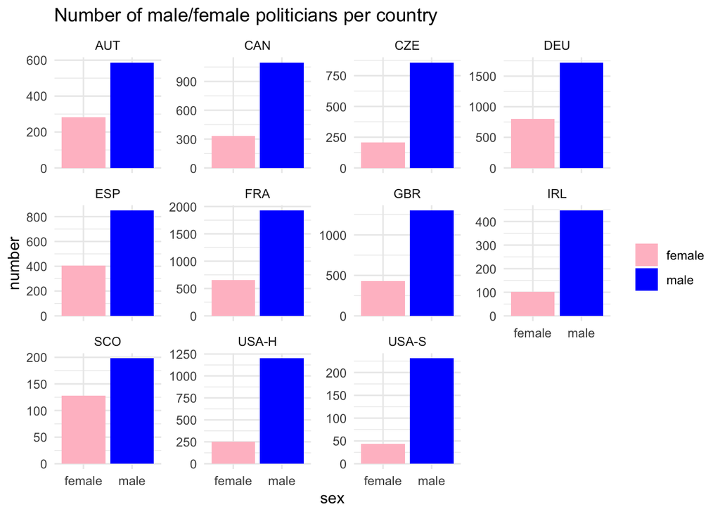

```r
#Plot the number of female/male politicians per country
ggplot(all_countries, aes(x = sex, fill = sex)) +
  geom_bar() +
  facet_wrap(~country, scales = "free_y") +
  labs(title = "Number of male/female politicians per country") +
  xlab("sex") +
  ylab("number") +
  scale_fill_manual(values = c("male" = "blue", "female" = "pink")) +
  theme_minimal() +
  theme(legend.title = element_blank())
```

We can see, that female politicians, as it can be expected, are underrepresented in all countries. Still, it leaves us with a decent number of female politicians to be compared to the male politicians.

Next, we want to have a look at the average monthly number of page views (traffic). This will be used to match female and male politicians in order to make them more comparable. Using this variable as matching variable is due to the hypothesis that “fame” represents the primary confounder variable, when it comes to the length of texts and the number of edits. As a proxy variable for fame this measure ensures that the analysis only examines comparable men and women.

```r
# deu_traffic <- get_traffic(legislature = "deu")
# deu_average_traffic <- traffic_metrics(deu_traffic)
# deu <- left_join(deu, select(deu_average_traffic, pageid, average_traffic), by = "pageid")
#
# fra_traffic <- get_traffic(legislature = "fra")
# fra_average_traffic <- traffic_metrics(fra_traffic)
# fra <- left_join(fra, select(fra_average_traffic, pageid, average_traffic), by = "pageid")
#
# #error
# gbr_traffic <- get_traffic(legislature = "gbr")
# gbr_average_traffic <- traffic_metrics(gbr_traffic)
# gbr$pageid <- as.character(gbr$pageid)
# gbr_average_traffic$pageid <- as.character(gbr_average_traffic$pageid)
# gbr <- left_join(gbr, select(gbr_average_traffic, pageid, average_traffic), by = "pageid")
# gbr$pageid <- as.numeric(gbr$pageid)
#
# can_traffic <- get_traffic(legislature = "can")
# can_average_traffic <- traffic_metrics(can_traffic)
# can <- left_join(can, select(can_average_traffic, pageid, average_traffic), by = "pageid")
#
# aut_traffic <- get_traffic(legislature = "aut")
# aut_average_traffic <- traffic_metrics(aut_traffic)
# aut <- left_join(aut, select(aut_average_traffic, pageid, average_traffic), by = "pageid")
#
#
# # introduces NAs exclusively, need to look into that
# esp_traffic <- get_traffic(legislature = "esp")
# esp_average_traffic <- traffic_metrics(esp_traffic)
# esp$pageid <- as.character(esp$pageid)
# esp_average_traffic$pageid <- as.character(esp_average_traffic$pageid)
# esp <- left_join(esp, select(esp_average_traffic, pageid, average_traffic), by = "pageid")
# esp$pageid <- as.numeric(esp$pageid)
#
# cze_traffic <- get_traffic(legislature = "cze")
# cze_average_traffic <- traffic_metrics(cze_traffic)
# cze <- left_join(cze, select(cze_average_traffic, pageid, average_traffic), by = "pageid")
#
# sco_traffic <- get_traffic(legislature = "sco")
# sco_average_traffic <- traffic_metrics(sco_traffic)
# sco <- left_join(sco, select(sco_average_traffic, pageid, average_traffic), by = "pageid")
#
# irl_traffic <- get_traffic(legislature = "irl")
# irl_average_traffic <- traffic_metrics(irl_traffic)
# irl <- left_join(irl, select(irl_average_traffic, pageid, average_traffic), by = "pageid")
#
# usa_house_traffic <- get_traffic(legislature = "usa_house")
# usa_senate_traffic <- get_traffic(legislature = "usa_senate")
#
# usa_traffic <- bind_rows(usa_house_traffic, usa_senate_traffic)
# usa_average_traffic <- traffic_metrics(usa_traffic)
# usa <- left_join(usa, select(usa_average_traffic, pageid, average_traffic), by = "pageid")
```

Let’s get some insights on the average traffic variable for all the countries by looking at the top pages and creating a boxplot per country and per sex

```r
# all_countries_traffic <- rbind(deu, cze, fra, usa, sco, irl, can, aut, esp, gbr)

#remove !is.na(sex)) as in some countries there are wikipedia pages of parties included, also, this analysis is based on a binary classification of gender for reasons of simplicity

# all_countries_traffic <- all_countries_traffic%>%
#   filter(!is.na(sex))
#
# write.csv(all_countries_traffic, file = "clean_data/all_countries_traffic", row.names = FALSE)

all_countries_traffic <- read.csv("clean_data/all_countries_traffic")
```

First, let’s look at the top 3 politicians for average monthly traffic per country as a sanity check and to get an idea of the data:

```r
all_countries_traffic %>%
  group_by(country) %>%
  arrange(desc(average_traffic)) %>%
  slice_head(n = 3)
```

```
## # A tibble: 33 × 14
## # Groups:   country [11]
##    country   pageid wikidataid wikititle    name  sex   ethnicity religion birth
##    <chr>      <int> <chr>      <chr>        <chr> <chr> <chr>     <chr>    <chr>
##  1 AUT      4554427 Q2262885   Sebastian_K… Kurz… male  white     catholi… 1986…
##  2 AUT      1936075 Q44733     Heinz-Chris… Stra… male  white     <NA>     1969…
##  3 AUT       169973 Q78869     Alexander_V… Van … male  white     catholi… 1944…
##  4 CAN       451733 Q3099714   Justin_Trud… Just… male  white     catholi… 1971…
##  5 CAN       241547 Q206       Stephen_Har… Step… male  white     protest… 1959…
##  6 CAN     33331329 Q6122681   Jagmeet_Sin… Jagm… male  <NA>      <NA>     1979…
##  7 CZE       336591 Q10819807  Andrej_Babiš Andr… male  white     <NA>     1954…
##  8 CZE        13605 Q29032     Miloš_Zeman  Milo… male  white     atheism  1944…
##  9 CZE        86549 Q58195     Karel_Schwa… Kare… male  white     catholi… 1937…
## 10 DEU          145 Q567       Angela_Merk… Ange… fema… white     protest… 1954…
## # ℹ 23 more rows
## # ℹ 5 more variables: death <lgl>, birthplace <chr>, deathplace <chr>,
## #   plain_text <chr>, average_traffic <dbl>
```

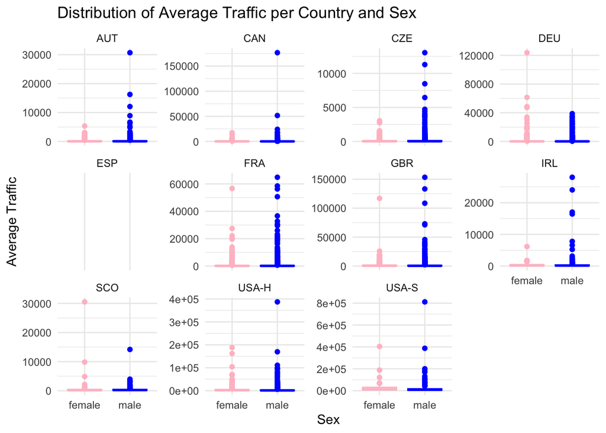

```r
ggplot(all_countries_traffic, aes(x = sex, y = average_traffic, color = sex)) +
  geom_boxplot() +
  facet_wrap(~country, scales = "free_y") +
  labs(title = "Distribution of Average Traffic per Country and Sex",
       x = "Sex",
       y = "Average Traffic") +
  scale_color_manual(values = c("male" = "blue", "female" = "pink")) +
  theme_minimal() +
  theme(legend.position = "none")
```

Zooming in, to be able to see the quartiles, leaving out some outliers:

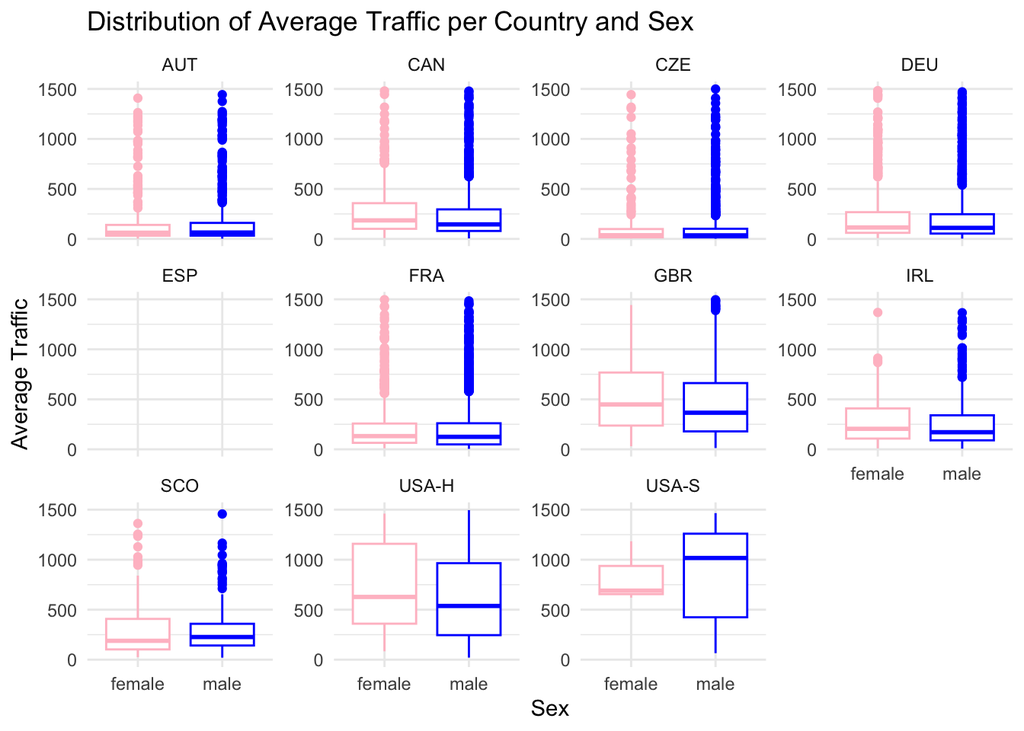

```r
#zoom in, focusing on quartiles, ignoring outliers
ggplot(all_countries_traffic, aes(x = sex, y = average_traffic, color = sex)) +
  geom_boxplot() +
  facet_wrap(~country, scales = "free_y") +
  labs(title = "Distribution of Average Traffic per Country and Sex",
       x = "Sex",
       y = "Average Traffic") +
  scale_color_manual(values = c("male" = "blue", "female" = "pink")) +
  theme_minimal() +
  theme(legend.position = "none") +
  ylim(1, 1500)  # Adjust the y-axis limits
```

Now, let’s have a look at the word counts for female and male politicians (for the further analysis, this data will be matched on confounding aspect of fame)

```r
#get word count

all_countries$word_count <- sapply(all_countries$plain_text, count_words)


avg_word_count <- all_countries %>%
  group_by(country, sex) %>%
  summarise(avg_word_count = mean(word_count))
```

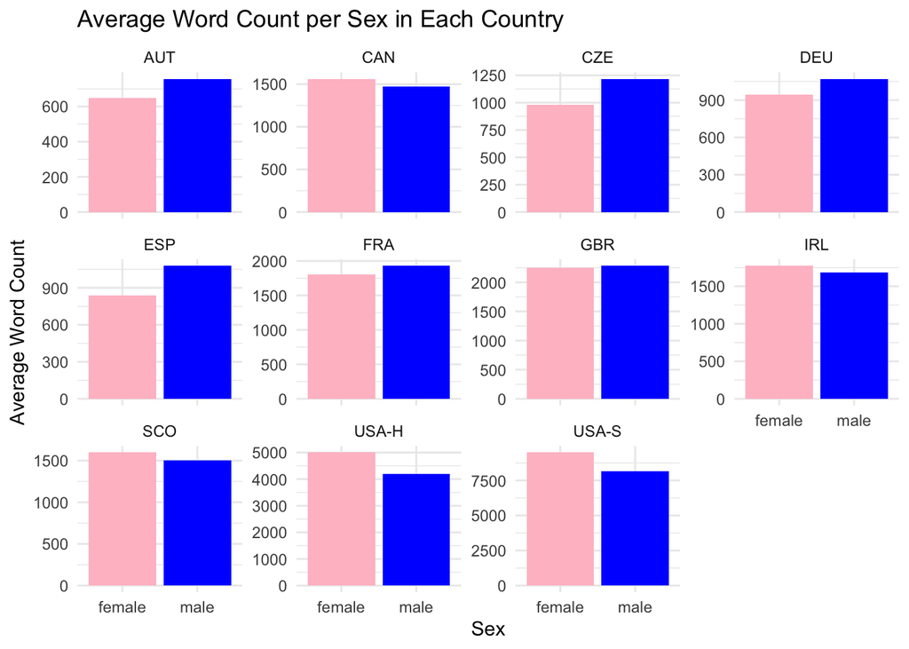

```r
ggplot(avg_word_count, aes(x = sex, y = avg_word_count, fill = sex)) +
  geom_bar(stat = "identity", position = "dodge") +
  facet_wrap(~ country, scales = "free_y") +
  labs(title = "Average Word Count per Sex in Each Country",
       x = "Sex",
       y = "Average Word Count") +
  scale_fill_manual(values = c("male" = "blue", "female" = "pink")) +
  theme_minimal() +
  theme(legend.position = "none")
```

Looking at the plots, the word count and the average number of traffic does not seem to be very different for males/females. Still, I suggest using average traffic as matching data to keep a balanced dataset for the analysis and exclude possible cofounders.